# EDAV PSet 2

Zhengyi Chen (zc2549), Keertan Krishnan (kk3446)

Read *Graphical Data Analysis with R*, Ch. 4, 5

Grading is based both on your graphs and verbal explanations. Follow all best practices as discussed in class.

### 1. Jungle Garden

Data: `garden_planting` from **gardenR** package

```r
#install.packages("remotes")
#remotes::install_github("llendway/gardenR")
```

For each of the following choose the appropriate data from the package and draw a bar chart, following best practices, that can directly answer the following questions. For each, explain your choice of bar order.

1. How many varieties of each type of vegetable were planted? **Answer:**

In this case, we have nominal data, which is rebinned by vegetable. Then their different types are counted and ordered by decreasing frequency. Flipped the axis to better present the name of vegetables and sorted by count, since the data is nominal.

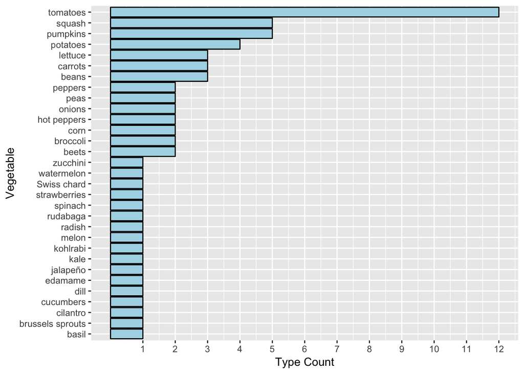

```r
library(gardenR)
library(dplyr)
library(ggplot2)
library(forcats)
datag <- gardenR::garden_planting
veggie_types <- summarise(group_by(datag, vegetable), count_types = n_distinct(variety))

type_plot <- ggplot(data=veggie_types, aes(x=fct_reorder(vegetable, count_types), y=count_types)) + geom_col(color='black', fill='light blue') + coord_flip() + ylab('Type Count') + xlab('Vegetable')+ scale_y_continuous(breaks=c(1,2,3,4,5,6,7,8,9,10,11,12,13))
type_plot
```

2. Were there any days of the week that Dr. Lendway never planted? Which days of the week was she most likely to be found planting? (Measure by the number of rows in `garden_planting`.) **Answer:**

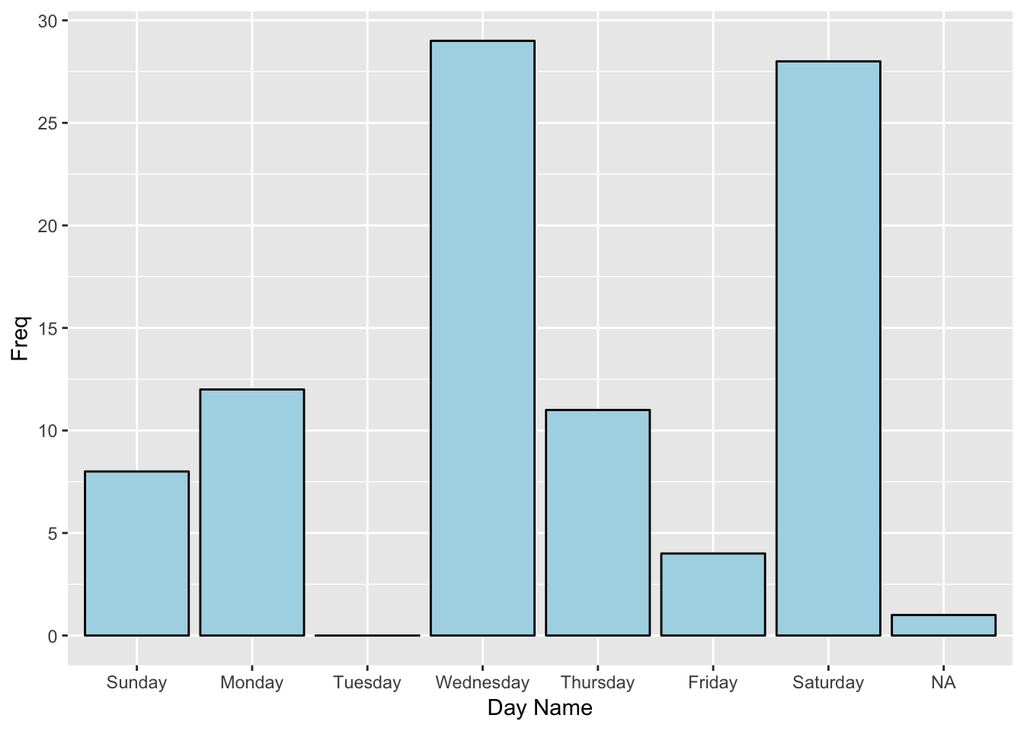

```r
days <- tibble(day=factor(weekdays(as.Date(datag$date,'%Y-%m-%d')), levels=c('Sunday', 'Monday', 'Tuesday', 'Wednesday', 'Thursday', 'Friday', 'Saturday')))
daysdf <- as.data.frame(table(weekdays(as.Date(datag$date,'%Y-%m-%d')), useNA = "ifany"))
names(daysdf) <- c("Day", "Freq")
new_row <- data.frame('Tuesday', 0)
names(new_row) <- c("Day", "Freq")
daysdf <- rbind(daysdf, new_row)
days_plot <- ggplot(data=daysdf, aes(x=fct_relevel(Day, 'Sunday', 'Monday', 'Tuesday', 'Wednesday', 'Thursday', 'Friday', 'Saturday'), y=Freq)) + geom_col(color='black', fill='light blue') + ylab('Freq') + xlab('Day Name')+ scale_y_continuous(breaks=c(0,5,10,15,20,25,30))
days_plot
```

We extracted the day of the week from the date. Then converted to data frame after finding frequencies. Once this was done, we found that Tuesday was not in this list. So we added in for Tuesday, and plotted geom_col, since data is already binned.

We consider the weekdays as ordinal data, hence we order them at the order from Sunday to Saturday.

From the barchart, we saw Dr. Lendway never plants on Tuesday.

Wednesdays and Saturdays are the two days when she was most likely to be found planting.

There is a unrecorded date and we represent it as NA in the chart.

3. How many seeds were planted in each plot?

**Answer:**

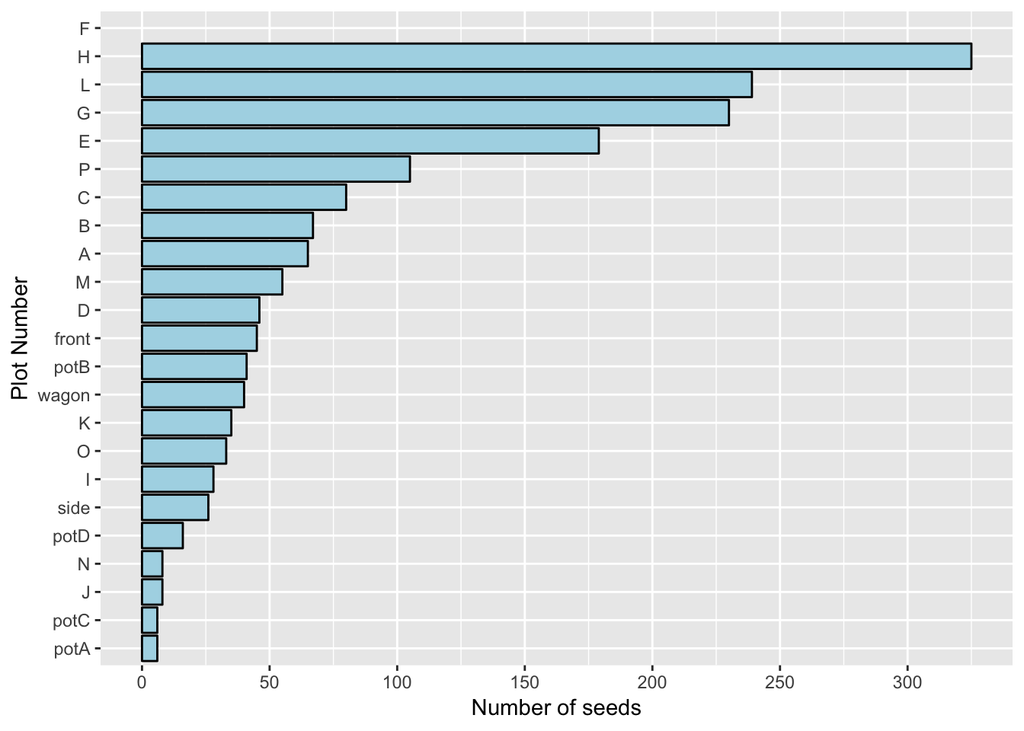

```r
plot_count <- summarise(group_by(datag, plot), seeds = sum(number_seeds_planted))
plots_plot <- ggplot(data=plot_count, aes(fct_reorder(plot, seeds), seeds)) + geom_col(color='black', fill='light blue') + ylab('Number of seeds') + xlab('Plot Number')+ scale_y_continuous(breaks=c(0,50,100,150,200,250,300)) + coord_flip()
plots_plot
```

In order to find the number of seeds planted in each plot, we group the data by the plot, then take the sum of the number of seeds planted for each row. While there are alphabets as names of the plots, there are also other names such as ‘front’. Hence, we assume it is nominal data and we order by the value of it.

### 2. Vaccination Rates

To get the data for this problem, we’ll scrape data from this page: https://www.beckershospitalreview.com/public-health/states-ranked-by-percentage-of-covid-19-vaccines-administered.html. Important: you should only execute parts (a) and (b) once. After running these lines, comment them out, and leave them commented out in the submitted version.

1. Check that it’s ok to scrape the site. What is the result?

**Answer:** First load needed packages and check:

```r
library(tidyverse)
library(rvest)
library(robotstxt)
library(readr)
library(dplyr)
library(zeallot)
paths_allowed("https://www.beckershospitalreview.com/public-health/states-ranked-by-percentage-of-covid-19-vaccines-administered.html")
```

```
## [1] TRUE
```

It’s ok to scrape the site!

2. Read the page at the URL listed above and save it.

**Answer:**

```r
web_data_raw <- read_html("https://www.beckershospitalreview.com/public-health/states-ranked-by-percentage-of-covid-19-vaccines-administered.html")
```

3. Read in the page saved in part b) and create a data frame with the following columns: `State`, `Distributed`, `Administered`, `Percentage`. Display the first six rows of the data frame.

**Answer:**

```r
web_data <- web_data_raw %>% html_nodes("ol")%>% html_nodes("li")
records <- vector("list", length = length(web_data))
for (i in seq_along(web_data)) {
    current_result = xml_contents(web_data[i])
    line <- current_result %>% html_text(trim = TRUE)
    line <- as.list(line)
    line <- line[line != ""]
    state <- toString(line[1])
    c(distribution,administrated,percentage) %<-%
      c(parse_number(toString(line[2])), parse_number(toString(line[3])),
        parse_number(toString(line[4])))

    records[[i]] <- data_frame(state = state, distribution = distribution,
                               administrated = administrated,
                               percentage = percentage)
}
df <- bind_rows(records)
head(df, 6)
```

```
## # A tibble: 6 x 4
##   state          distribution administrated percentage
##   <chr>                 <dbl>         <dbl>      <dbl>
## 1 North Dakota         131625        126822       96.4
## 2 New Mexico           364875        331793       90.9
## 3 West Virginia        357000        322046       90.2
## 4 Montana              163675        137765       84.2
## 5 South Carolina       684700        568917       83.1
## 6 South Dakota         161150        131439       81.6
```

4. Create a Cleveland dot plot showing the percentage of distributed vaccines that have been administered.

**Answer:**

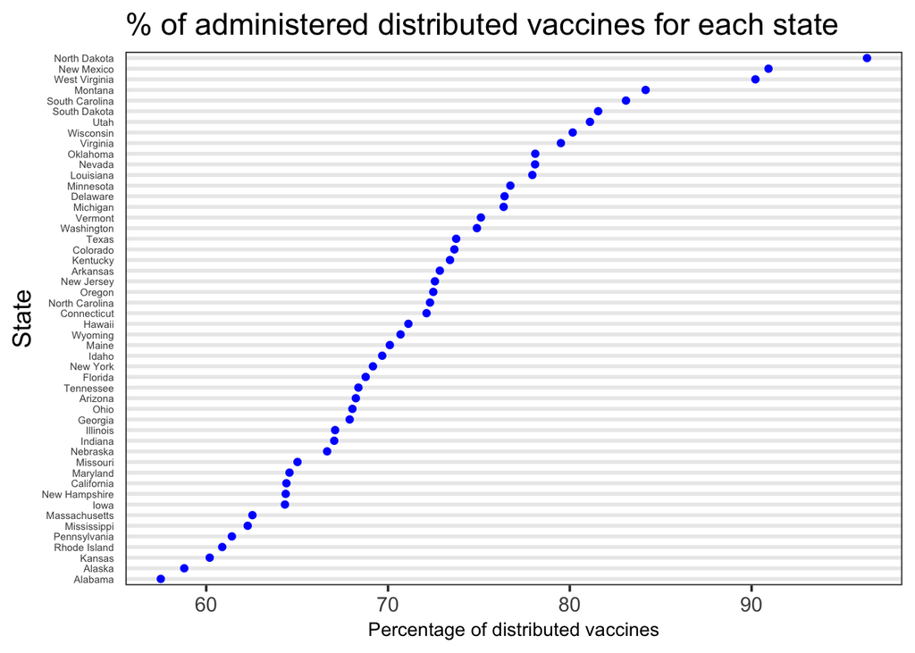

```r
# create a theme for dot plots, which can be reused
theme_dotplot <- theme_bw(14) +
    theme(axis.text.y = element_text(size = rel(.5)),
        axis.ticks.y = element_blank(),
        axis.title.x = element_text(size = rel(.75)),
        panel.grid.major.x = element_blank(),
        panel.grid.major.y = element_line(size = 1),
        panel.grid.minor.x = element_blank())

# create the plot
ggplot(df, aes(x = percentage,
               y = reorder(state, percentage))) +
    geom_point(color = "blue") +
    theme_dotplot +
    xlab("Percentage of distributed vaccines") +
    ylab("State") +
    ggtitle("% of administered distributed vaccines for each state")
```

5. Create a multiple Cleveland dot plot showing doses distributed in one color and doses administered in another for each state. Experiment with different sorting orders. Choose the one that you think works best and explain why. **Answer:**

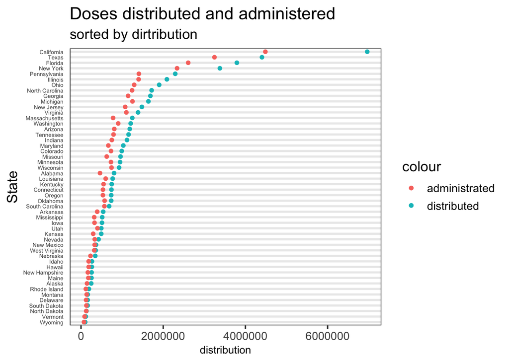

```r
# create a theme for dot plots, which can be reused
theme_dotplot <- theme_bw(14) +
    theme(axis.text.y = element_text(size = rel(.5)),
        axis.ticks.y = element_blank(),
        axis.title.x = element_text(size = rel(.75)),
        panel.grid.major.x = element_blank(),
        panel.grid.major.y = element_line(size = 1),
        panel.grid.minor.x = element_blank())
options(scipen = 9)
ggplot(df) +
  geom_point(aes(distribution, reorder(state, distribution), color = 'distributed')) +
  geom_point(aes(administrated, reorder(state, distribution), color = 'administrated')) +
  ggtitle("Doses distributed and administered", sub = "sorted by dirtribution") + ylab("State") +
  theme_dotplot
```

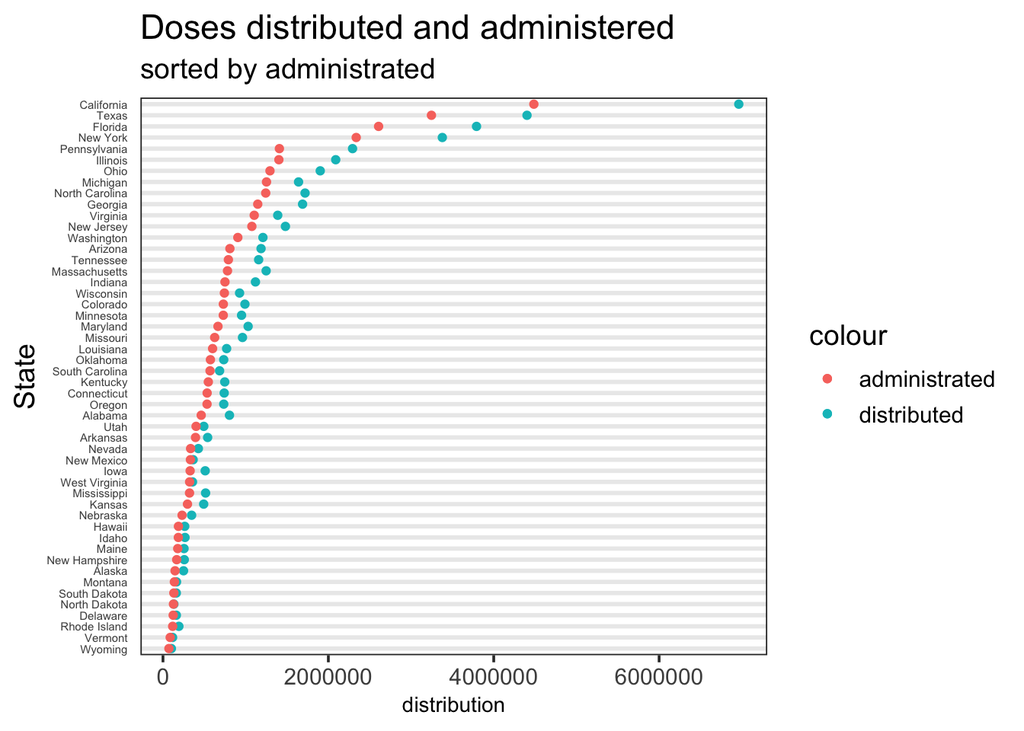

```r
# create a theme for dot plots, which can be reused
theme_dotplot <- theme_bw(14) +
    theme(axis.text.y = element_text(size = rel(.5)),
        axis.ticks.y = element_blank(),
        axis.title.x = element_text(size = rel(.75)),
        panel.grid.major.x = element_blank(),
        panel.grid.major.y = element_line(size = 1),
        panel.grid.minor.x = element_blank())
options(scipen = 9)
ggplot(df) +
  geom_point(aes(distribution, reorder(state, administrated) , color = 'distributed')) +
  geom_point(aes(administrated, reorder(state, administrated), color = 'administrated')) +
  ggtitle("Doses distributed and administered", sub = "sorted by administrated") + ylab("State") +
  theme_dotplot
```

After comparing with two plots(the first one is sort by distribution and the second one is sort by administrated), we can see that the other variable do not display strict monotonicity, which is normal since the two variables may not be linearly related.

We think the first graph is relatively better since when sorting by distribution, the trend for administrated is very similar to monotonic function. However, for the second graph, the middle part is kind of messy and hard to get an idea about the order of distribution from the graph.

### 3. Taxis

Data: NYC yellow cab rides in June 2020, available here:

https://www1.nyc.gov/site/tlc/about/tlc-trip-record-data.page

It’s a large file so you may work with a reasonably-sized random sample of the data (for example 10000 rows). If you remove outliers / impossibilities explain your logic.

```r
yellow <- read.csv('yellow_tripdata_2020-06.csv')
```

```r
summary(yellow)
```

```
##     VendorID              tpep_pickup_datetime         tpep_dropoff_datetime
##  Min.   :1.0     2020-06-18 21:07:47:    12    2020-06-18 21:07:47:    12
##  1st Qu.:1.0     2020-06-03 23:52:00:     8    2020-06-24 04:52:00:     9
##  Median :2.0     2020-06-10 23:13:00:     8    2020-06-25 00:00:00:     9
##  Mean   :1.6     2020-06-12 04:36:00:     8    2020-06-28 00:00:00:     9
##  3rd Qu.:2.0     2020-06-15 04:44:00:     8    2020-06-05 00:00:00:     8
##  Max.   :2.0     2020-06-18 04:35:00:     8    2020-06-09 00:00:00:     8
##  NA's   :50717   (Other)            :549708    (Other)            :549705
##  passenger_count trip_distance         RatecodeID    store_and_fwd_flag
##  Min.   :0.00    Min.   :     0.00   Min.   : 1.00    : 50717
##  1st Qu.:1.00    1st Qu.:     1.01   1st Qu.: 1.00   N:495281
##  Median :1.00    Median :     1.86   Median : 1.00   Y:  3762
##  Mean   :1.36    Mean   :     4.10   Mean   : 1.05
##  3rd Qu.:1.00    3rd Qu.:     3.66   3rd Qu.: 1.00
##  Max.   :9.00    Max.   :220386.23   Max.   :99.00
##  NA's   :50717                       NA's   :50717
##   PULocationID    DOLocationID    payment_type    fare_amount
##  Min.   :  1.0   Min.   :  1.0   Min.   :1.00    Min.   :-216.00
##  1st Qu.:107.0   1st Qu.: 87.0   1st Qu.:1.00    1st Qu.:   6.00
##  Median :151.0   Median :151.0   Median :1.00    Median :   9.00
##  Mean   :157.6   Mean   :153.5   Mean   :1.37    Mean   :  13.61
##  3rd Qu.:234.0   3rd Qu.:233.0   3rd Qu.:2.00    3rd Qu.:  15.50
##  Max.   :265.0   Max.   :265.0   Max.   :5.00    Max.   : 941.50
##                                  NA's   :50717
##      extra           mta_tax          tip_amount       tolls_amount
##  Min.   :-4.500   Min.   :-0.5000   Min.   :-36.300   Min.   :-28.7500
##  1st Qu.: 0.000   1st Qu.: 0.5000   1st Qu.:  0.000   1st Qu.:  0.0000
##  Median : 0.500   Median : 0.5000   Median :  1.500   Median :  0.0000
##  Mean   : 1.024   Mean   : 0.4913   Mean   :  1.763   Mean   :  0.3671
##  3rd Qu.: 2.500   3rd Qu.: 0.5000   3rd Qu.:  2.750   3rd Qu.:  0.0000
##  Max.   :87.560   Max.   : 3.3000   Max.   :422.680   Max.   :114.7500
##
##  improvement_surcharge  total_amount     congestion_surcharge
##  Min.   :-0.300        Min.   :-216.30   Min.   :-2.500
##  1st Qu.: 0.300        1st Qu.:  10.70   1st Qu.: 2.500
##  Median : 0.300        Median :  14.16   Median : 2.500
##  Mean   : 0.297        Mean   :  18.77   Mean   : 1.968
##  3rd Qu.: 0.300        3rd Qu.:  20.80   3rd Qu.: 2.500
##  Max.   : 0.300        Max.   :1141.10   Max.   : 2.500
##
```

Draw four plots of `tip_amount` vs. `fare_amount` with the following variations:

1. Scatterplot with alpha blending

Impossibilities are removed by the following criteria: 1) Fare amount must be greater than 0 2) Tip amount must be non-negative In addition, we take a sample of 10000 rows, as the dataset is too large to plot legibly. Thus, we are assuming 10000 is a number that is large enough to accurately capture the characteristics of the dataset. Also, extreme outliers of tips greater than 150 are removed and fare amounts greater than 500 are removed as there cases are extremely rare and not representative of the general pattern.

In the first graph, we only present the fares up to 40 dollars since this is where the majority of the data is.

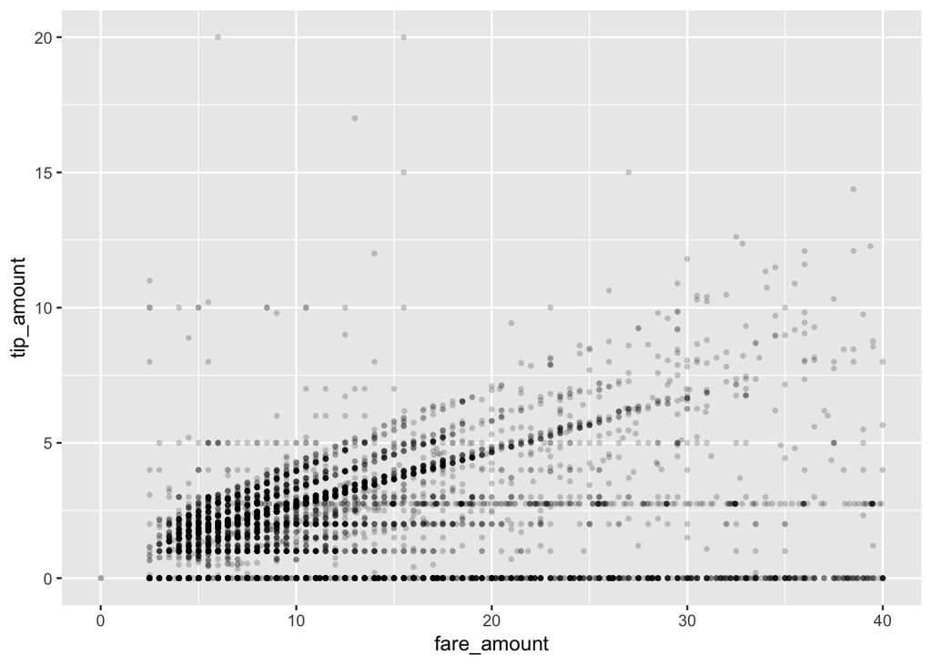

```r
# Remove impossibilities
yellow <- yellow[yellow$fare_amount>0,]
yellow <- yellow[yellow$tip_amount>=0,]
# Removing extreme outliers as they interfere with the presentation of the plots
yellow <- yellow[yellow$tip_amount<150, ]
yellow <- yellow[yellow$fare_amount<500, ]
yellow <- yellow[sample(1:nrow(yellow),10000, replace = F),]
yellow_scatter <- ggplot(yellow, aes(x=fare_amount, y=tip_amount)) + geom_point(alpha=0.2, stroke=0) + ylim(0,20) + xlim(0, 40) #+ scale_x_log10(breaks=c(5,10,15,20,40, 100)) + scale_y_log10(breaks=c(2,5,10,15,20,40))
yellow_scatter
```

In order to gain further insight into the data, we have also faceted the data based on quantiles. It is clear that the largest proportion of fare amounts are between $5 to $8, making up 30% of the data in terms of percentile.

```r
yellow_copy <- yellow[yellow$fare_amount<=100, ]
yellow_copy <- yellow_copy[yellow_copy$tip_amount<=30, ]
binnedyellow <- yellow_copy%>%
  mutate(mybin=ntile(fare_amount, 10)) %>%
  dplyr::select(tip_amount, fare_amount, mybin)
head(binnedyellow)
```

```
##   tip_amount fare_amount mybin
## 1       3.26        12.5     7
## 2       3.45        10.5     6
## 3       1.50         7.0     4
## 4       1.96         6.5     3
## 5       2.26         7.5     4
## 6       0.00        45.7    10
```

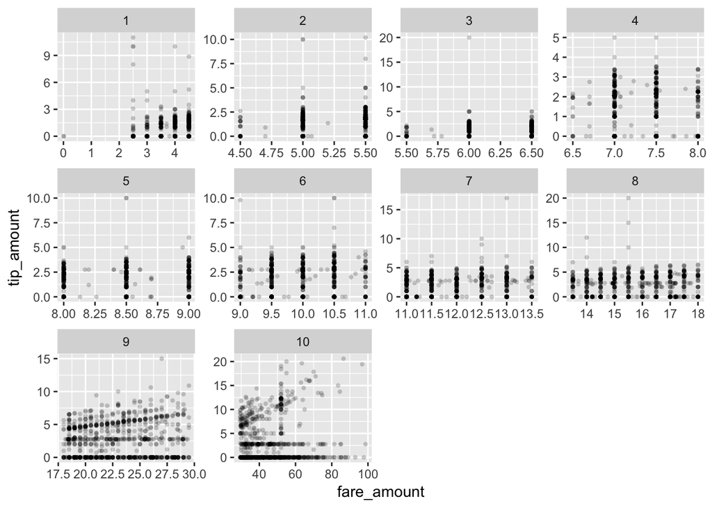

```r
ggplot(binnedyellow, aes(fare_amount, tip_amount)) + geom_point(alpha=0.2, stroke=0) + facet_wrap(~mybin,scales="free")
```

2. Scatterplot with alpha blending + density estimate contour lines

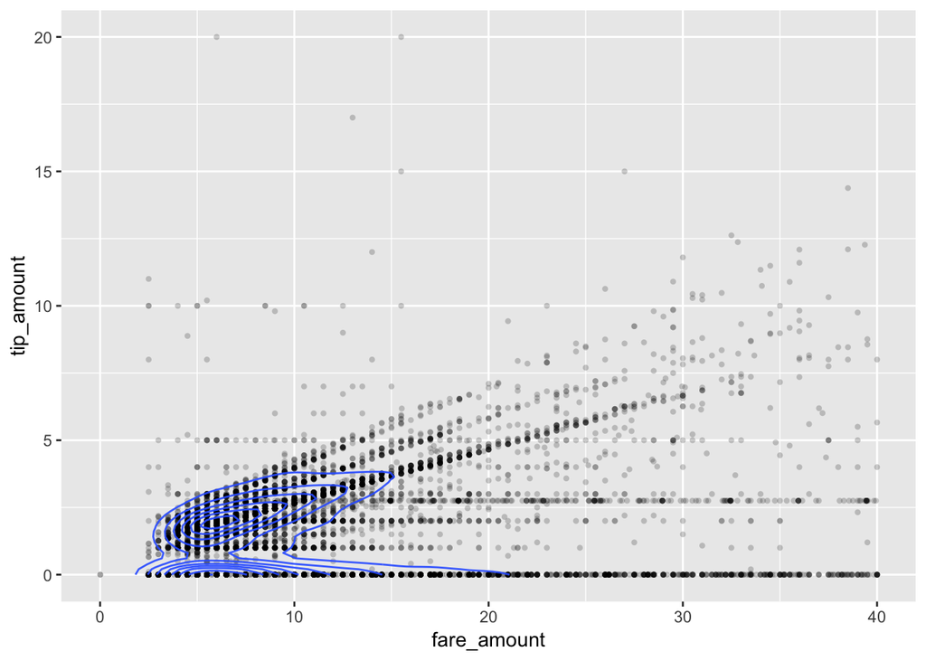

```r
yellow_scatter <- ggplot(yellow, aes(x=fare_amount, y=tip_amount)) + geom_point(alpha=0.2,stroke=0, na.rm=TRUE)+stat_density2d(alpha=0.9, bins=8, na.rm=TRUE) + ylim(0,20) + xlim(0, 40)
yellow_scatter
```

The density estimate contour lines reflect the fact that most of the data is concentrated within the 16 dollar range for the fare amount.

3. Hexagonal heatmap of bin counts

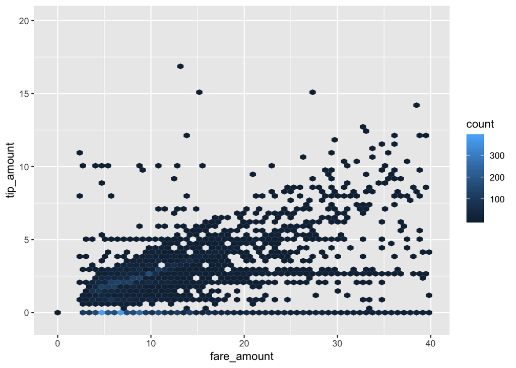

```r
hex <- ggplot(yellow, aes(x=fare_amount, y=tip_amount))
hex+geom_hex(bins=60, na.rm=TRUE) +ylim(-.5,20) + xlim(-.5, 40)
```

The hexagonal heatmap shows the regions where the data is highly concentrated. Even though the tip and fare amounts can never be negative, the limits of the axes are set as such so that bins corresponding to 0 tips are plotted, which does not occur if xlim/ylim are set as (0, some_value).

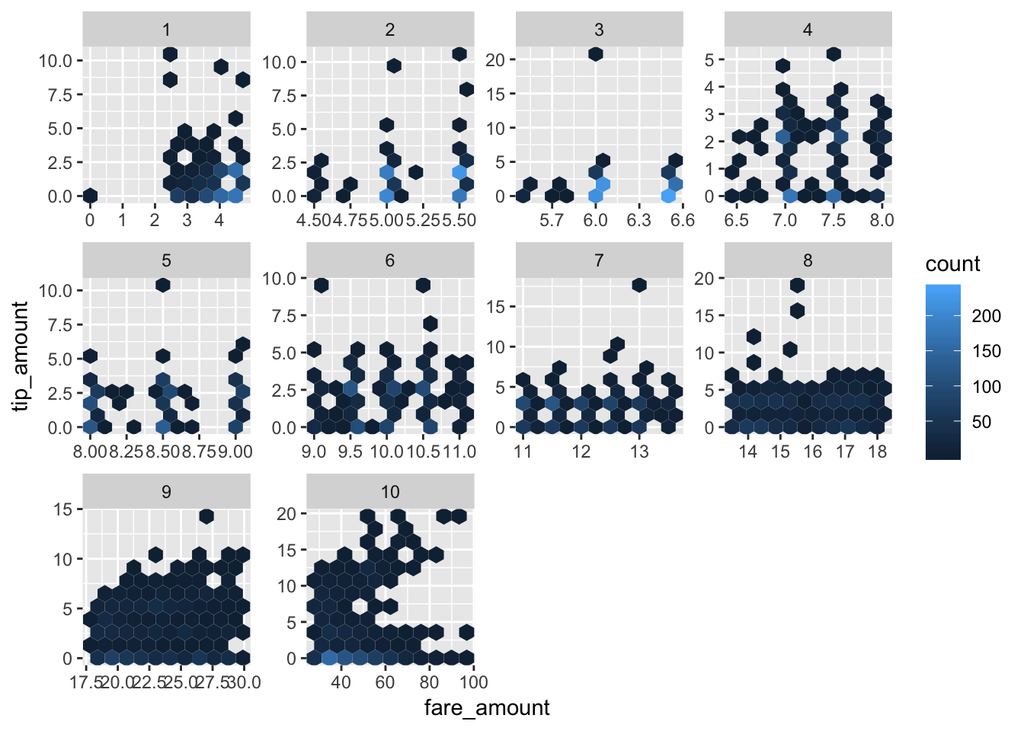

```r
ggplot(binnedyellow, aes(fare_amount, tip_amount)) + geom_hex(bins=10, na.rm=TRUE) + facet_wrap(~mybin,scales="free")
```

Faceting by quantiles gives us addditional insight into the data.

4. Square heatmap of bin counts

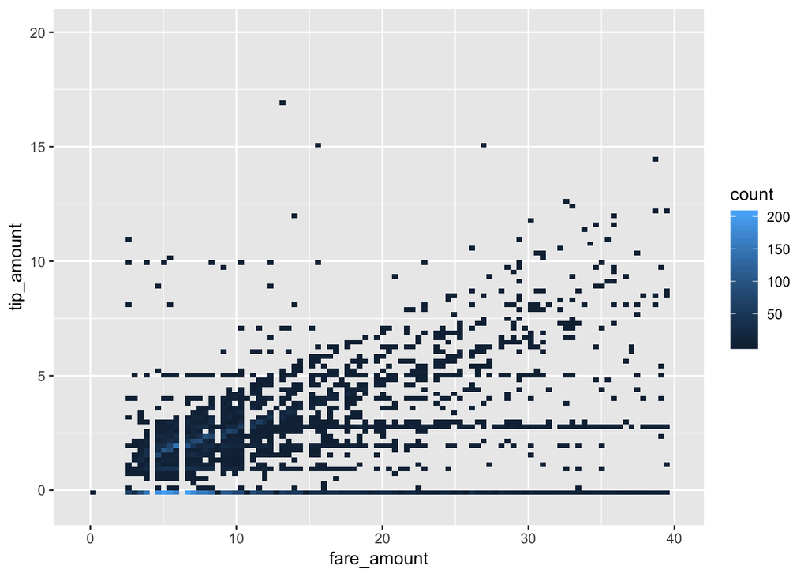

```r
d <- ggplot(yellow, aes(fare_amount, tip_amount))
d + geom_bin2d(bins=100, na.rm=TRUE)+ylim(-0.5,20) + xlim(-0.5, 40)
```

The square heatmap shows the regions where the data is highly concentrated. Even though the tip and fare amounts can never be negative, the limits of the axes are set as such so that bins corresponding to 0 tips are plotted, which does not occur if xlim/ylim are set as (0, some_value).

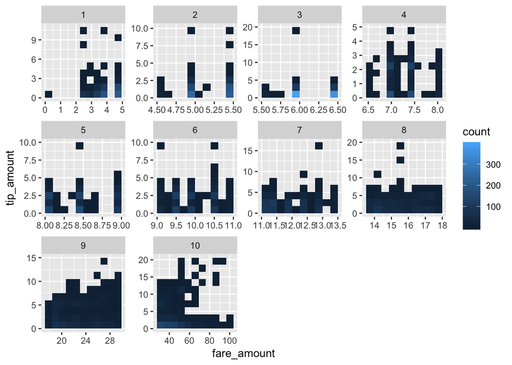

```r
ggplot(binnedyellow, aes(fare_amount, tip_amount)) + geom_bin2d(bins=10, na.rm=TRUE) + facet_wrap(~mybin,scales="free")
```

Faceting by quantiles gives us addditional insight into the data.

For all, adjust parameters to the levels that provide the best views of the data.

5. Describe noteworthy features of the data, using the “Movie ratings” example on page 82 (last page of Section 5.3) as a guide.

**Answer:** 1. Most of the data points are distributed at the region of tip_amount between 0 and 20 and fare_amount between 0 and 50.

2. There are rarely situations where the fare_amount is low whereas the tip_amount is high.
3. From the contour lines and Square heatmap, we can observe that there is a line, which approximately goes through the line: tip_ampunt = 0.25fare_amount. Hence we can deduce that many people pay 25% tips of fare amount.
4. Many people gives 0 tips no matter how much the fare amount is.
5. Many people gives 1, 2, 3 and 5 dollars tip no matter how much the fare amount is, maybe it is beacuse that people tend to give a integer amount which are easier for them to calculate.
6. The spread of tip_amount is increasing while the fare_amount is increasing.
7. There are also some situations, even though not common, where the fare amount is relatively low but the tips are high.
8. For those who pay tips(tip_amount > 0), they tend to pay high value tips.
9. There are also other patterns for a regression line in the scatter plot. It is due to that people tend to give certain percent of the fare amount as tip amount.